# week4 assignments

Christopher Brown

September 30, 2015

# Readings

In **Applied Predictive Modeling** (APM), Read: - Chapter 4 - Overfitting and Model Tuning - Chapter 5 - Regression Models - Chapter 6 , esp. 6.2 - Linear Regression - Chapter 12.2 - Logistic Regression

- [A Short Introduction to the Caret Package](https://cran.r-project.org/web/packages/caret/vignettes/caret.pdf). Make sure that you work along with the text.

# Problem Set

DUE: *In Class Monday October 12th*

The assigments are designed to be completed using [RMarkdown](http://rmarkdown.rstudio.com/).

> R Markdown is an authoring format that enables easy creation of dynamic documents, presentations, and reports from R. It combines the core syntax of markdown (an easy-to-write plain text format) with embedded R code chunks that are run so their output can be included in the final document. R Markdown documents are fully reproducible (they can be automatically regenerated whenever underlying R code or data changes).

For questions requiring:

- textual answers: record your answer in plain text
- code: place the code in the RMarkdown code fence.

Show all code used to arrive at the answers.

## Finish in-class assignments

## *APM* 6.2 (a)-(d)

```r
# Place your code here
library(AppliedPredictiveModeling)
data(permeability)
```

1. No response required.

```r
# place R code here
library(caret)
ncol(fingerprints)
```

```
## [1] 1107
```

```r
nzv_cols = nearZeroVar(fingerprints)
if(length(nzv_cols) > 0) {
    fingerprints <- fingerprints[, -nzv_cols]
}
ncol(fingerprints)
```

```
## [1] 388
```

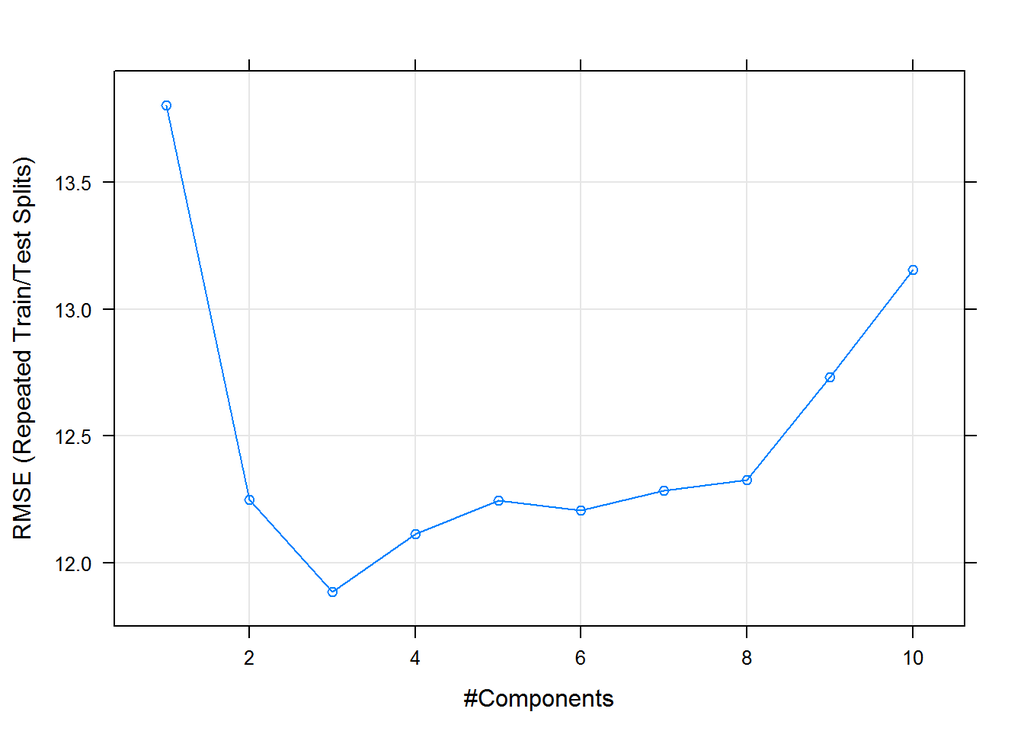

```r
# place R code here
library(caTools)
set.seed(123456)
split = sample.split(permeability, SplitRatio = 0.7)
train = subset(fingerprints, split==TRUE)
test = subset(fingerprints, split==FALSE)
perm_train = subset(permeability, split==TRUE)
perm_test = subset(permeability, split==FALSE)

# library(pls)
# pls1 = mvr(perm_train ~ train)
# summary(pls1)
# plot(pls1)
set.seed(123456)
pls = train(x = train, y = perm_train, method = "pls", tuneGrid = expand.grid(ncomp = 1:10), trControl = trainControl(method = "LGOCV"))
ncomp = 1:10
plot(pls)
```

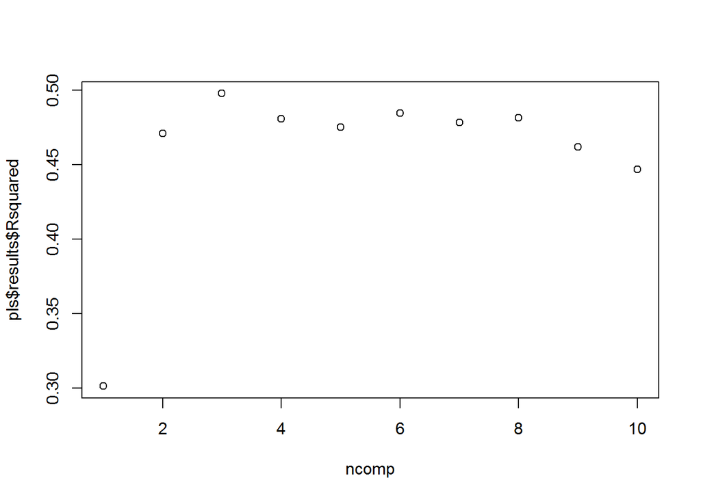

```r
plot(ncomp, pls$results$Rsquared)
```

```r
min(pls$results$Rsquared)
```

```
## [1] 0.3013563
```

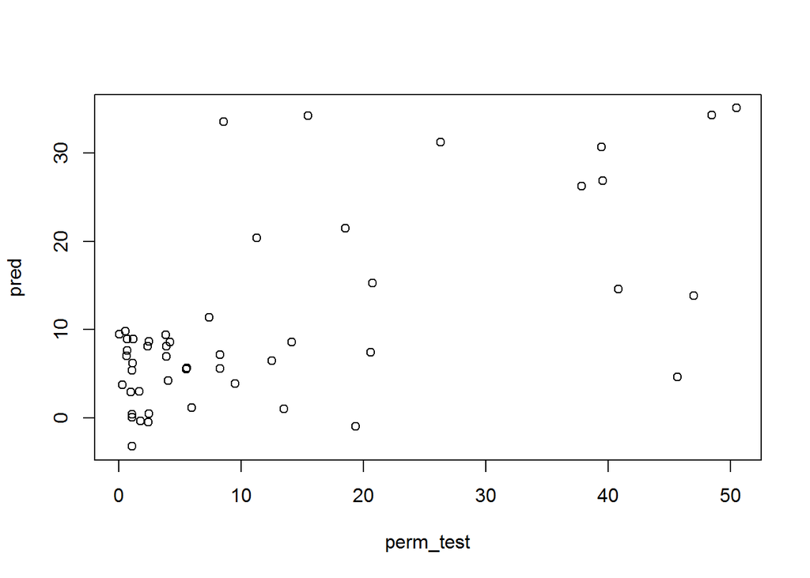

```r
# place R code here
pred = predict(pls, newdata=test)
plot(perm_test, pred)
```

## German Credit Data

The University of California, Irvine [Machine Learning Repository](https://archive.ics.uci.edu/ml/index.html). One popular data set is the [German Credit Data](https://archive.ics.uci.edu/ml/datasets/Statlog+%28German+Credit+Data). Using this data, create a logistic regression model.

```r
data(GermanCredit)
set.seed(123456)
split = sample.split(GermanCredit$Class, SplitRatio = 0.7)
train = subset(GermanCredit, split==TRUE)
test = subset(GermanCredit, split==FALSE)

# Reference: APM pp. 85 - 87
svmFit = train(Class ~ ., data = train, method = "svmRadial", preProc = c("center", "scale"), tuneLength = 10, trControl = trainControl(method = "repeatedcv", repeats = 5))
```

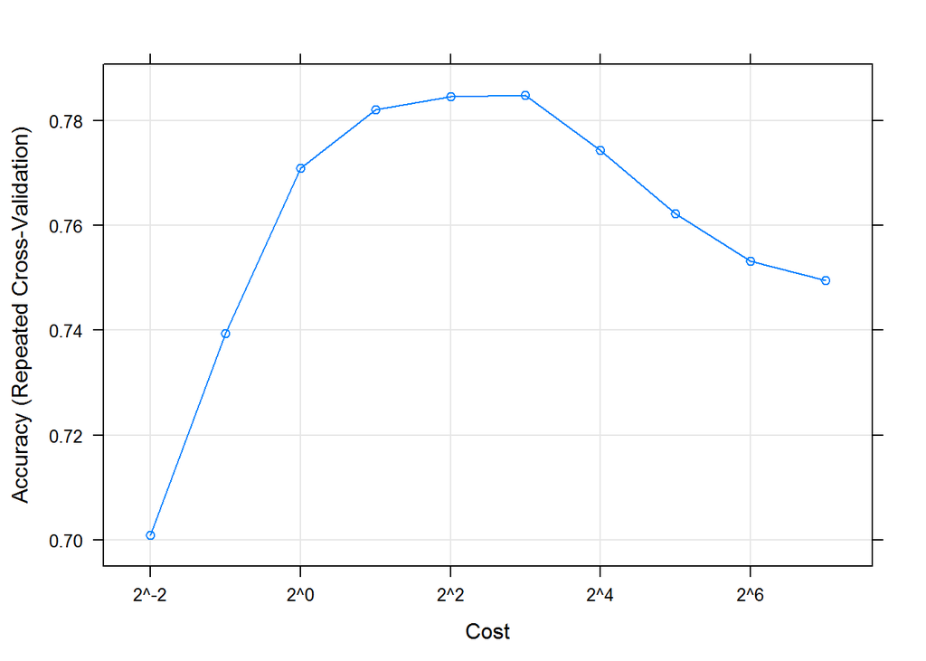

```r
plot(svmFit, scales = list(x = list(log = 2)))
```

```r
svmFit
```

```
## Support Vector Machines with Radial Basis Function Kernel
##
## 700 samples
##  61 predictor
##   2 classes: 'Bad', 'Good'
##
## Pre-processing: centered, scaled
## Resampling: Cross-Validated (10 fold, repeated 5 times)
## Summary of sample sizes: 630, 630, 630, 630, 630, 630, ...
## Resampling results across tuning parameters:
##
##   C       Accuracy   Kappa        Accuracy SD  Kappa SD
##     0.25  0.7008571  0.004659179  0.003427113  0.01635127
##     0.50  0.7394286  0.223447138  0.027160498  0.09219127
##     1.00  0.7708571  0.389217808  0.042511728  0.11367274
##     2.00  0.7820000  0.440282141  0.049048421  0.12566084
##     4.00  0.7845714  0.458837640  0.046702154  0.11819193
##     8.00  0.7848571  0.465885459  0.042555792  0.10673114
##    16.00  0.7742857  0.445546991  0.044149607  0.11374645
##    32.00  0.7622857  0.421509760  0.041500390  0.10723351
##    64.00  0.7531429  0.402981465  0.043392190  0.10531901
##   128.00  0.7494286  0.394696414  0.043408504  0.10599826
##
## Tuning parameter 'sigma' was held constant at a value of 0.01013969
## Accuracy was used to select the optimal model using  the largest value.
## The final values used for the model were sigma = 0.01013969 and C = 8.
```

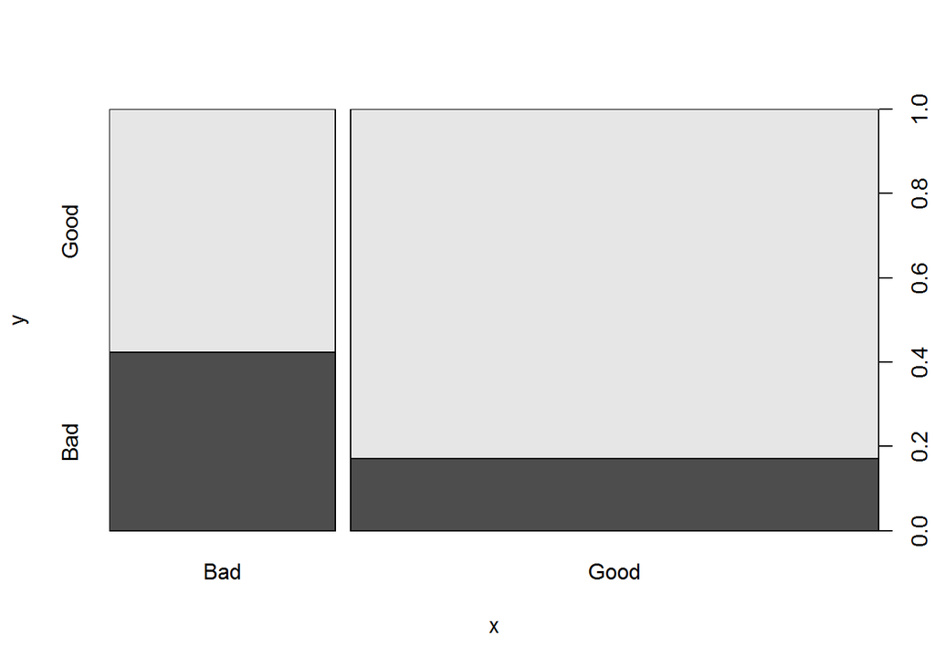

```r
pred = predict(svmFit, test)
plot(test$Class, pred)
```